# Lista 4 - Classificação de imagens

Matheus Stivali

16/10/2021

# Introdução

O objetivo deste trabalho é implementar uma rede neural convolucional (RNC) na linguagem R capaz de classificar as imagens de impressões digitais quanto ao sexo da pessoa.

O banco de dados está dividido em um conjunto de treino, com 740 impressões digitais de mulheres e 3260 impressões digitais de homens, e um conjunto de teste com 2000 impressões digitais. As imagens do banco estão em formato bitmap (BMP) e em sua maioria elas têm definição **definição de 96 pixels de largura e 103 pixels de altura**. Contudo, há 40 imagens com dimensões maiores (241x298 pixels) no banco de treino e 4 imagens com essas dimensões no banco de teste.

Apenas as imagens do banco de treino possuem identificação e dependendo a implementação os arquivos dessas imagens foram mantidos na mesma pasta ou divididos em pastas diferentes de acordo com sua identificação.

# 1. Implementação 1 - Imagemagick + Keras

Esta implementação faz a leitura, pré-processamento, e conversão dos arquivos de imagem em arrays de dados pelo pacote Imagemagick e posterior análise e classificação pelo Keras/Tensorflow.

As imagens originalmente em formato Bitmap lidas pelo default do imagemagick como `colorspace = sRGB`, resultando em 4 canais (Red, Gray, Blue, e White point). Pela natureza das imagens que não tem características de cor relavantes, optou-se pela conversão em tons de cinza (`colorspace = gray`), com apenas 1 canal.

O tamanho das imagens foi padronizado com o comando `image_resize`, mas foi necessário forçar a definição uma vez que a razão entre as dimensões 241x298 e 96x103 é diferente.

```r
#######################################################
## Identificando os arquivos e carregando as figuras
#######################################################
treino <- "E:/Dropbox/Estatística-UnB/Redes Neurais Profundas/R/Dados/Treino2"
teste <- "E:/Dropbox/Estatística-UnB/Redes Neurais Profundas/R/Dados/Teste"
categorias <- list.dirs(treino)[-1]
names(categorias) <- c("Homem", "Mulher")


## Lista dos arquivos
arq_trein <- categorias %>%
                    map( ~ list.files(., full.names = TRUE))

## Carregando e convertendo de RGB para Grayscale
fig_trein <- arq_trein %>%
                       map( ~ image_read(.)) %>%
                       map( ~ image_convert(., colorspace = "gray"))

length(fig_trein$Homem)
```

```
## [1] 3260
```

```r
length(fig_trein$Mulher)
```

```
## [1] 740
```

```r
#######################################################
## Ajuste de tamanho
#######################################################
unique(image_info(fig_trein$Homem)$width)
```

```
## [1]  96 241
```

```r
unique(image_info(fig_trein$Mulher)$width)
```

```
## [1]  96 241
```

```r
fig_trein$larg_H <- image_info(fig_trein$Homem)$width
fig_trein$larg_M <- image_info(fig_trein$Mulher)$width

for(i in 1:length(fig_trein$Homem)){
  if(fig_trein$larg_H[i]==241){
    fig_trein$Homem[i] <- image_resize(fig_trein$Homem[i],"96x103!")
  }
}
rm(i)
for(i in 1:length(fig_trein$Mulher)){
  if(fig_trein$larg_M[i]==241){
    fig_trein$Mulher[i] <- image_resize(fig_trein$Mulher[i],"96x103!")
  }
}
rm(i)

unique(image_info(fig_trein$Homem)$width)
```

```
## [1] 96
```

```r
unique(image_info(fig_trein$Mulher)$width)
```

```
## [1] 96
```

```r
fig_trein <- fig_trein[-c(3,4)]

#######################################################
## Rótulos
#######################################################
rot_trein <- arq_trein %>%
                       map( ~ str_extract(., regex("M_|F_"))) %>%
                       map( ~ strtrim(., 1))


rot_trein2 <- rot_trein %>%
                        unlist() %>%
                        as.data.frame()

rownames(rot_trein2) <- NULL
colnames(rot_trein2) <- c("Sexo")
rot_trein2$Mulher <- 0
rot_trein2$Mulher[rot_trein$Sexo=="F"] <- 1
```

Com os objetos de imagem e rótulos devidamente criados o passo seguinte é a conversão das imagens em arrays com as informações das imagens.

```r
#######################################################
## Figuras em formato de matrizes
#######################################################

fig_matriz <- vector(length(fig_trein), mode="list")

for(i in 1:2) {
  fig_matriz[[i]] <- map(1:length(fig_trein[[i]]),
                       ~ as.integer(
                         image_data(
                           fig_trein[[i]][.]
                         )
                       )
  )
  names(fig_matriz[[i]]) <- rot_trein[[i]]
}

names(fig_matriz) <- c("Homem", "Mulher")
```

A análise inicial dos arrays mostra algumas diferenças sutis entre as impressões de homens e mulheres. Há maior proporção de pixels pretos nas impressões de homens em relação a das mulheres (o que poderia representar que, em média, os dedos dos homens são maiores que o das mulheres).

```r
################################################
## Análise Inicial
################################################

## Proporção de pixels pretos nas digitais
mulheres <- fig_matriz$Mulher %>%
                             map_dbl( ~ mean(.==0))

homens <- fig_matriz$Homem %>%
                           map_dbl( ~ mean(.==0))

summary(mulheres)
```

```
##     Min.  1st Qu.   Median     Mean  3rd Qu.     Max.
## 0.000000 0.008192 0.105178 0.107561 0.159992 0.576760
```

```r
summary(homens)
```

```
##    Min. 1st Qu.  Median    Mean 3rd Qu.    Max.
## 0.00000 0.06088 0.12050 0.12270 0.17602 0.64442
```

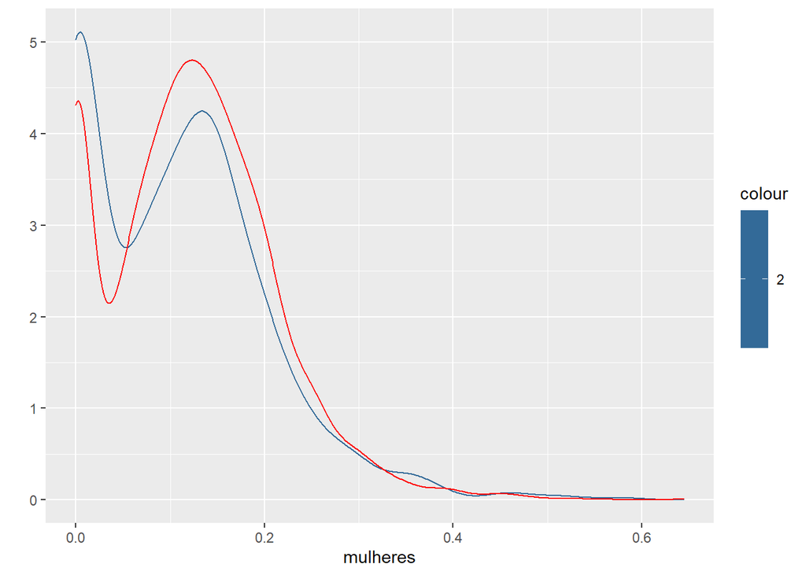

```r
qplot(mulheres, geom="density", col = 2) +
    geom_density(aes(homens), colour="red")
```

```r
################################################
## Implementação no Keras
################################################

modelo <- keras_model_sequential()

modelo %>%
          layer_conv_2d(filters = 30,
                        kernel_size = c(5,5),
                        activation = "relu",
                        input_shape = c(103,96,1)) %>%
          layer_conv_2d(filters = 30,
                kernel_size = c(3,3),
                activation = "relu") %>%
          layer_dropout(rate = 0.2)  %>%
          layer_conv_2d(filters = 60,
                kernel_size = c(3,3),
                activation = "relu") %>%
          layer_conv_2d(filters = 60,
                kernel_size = c(3,3),
                activation = "relu") %>% # activation = NULL
          layer_max_pooling_2d(pool_size = c(2,2)) %>%
          layer_dropout(rate = 0.2)  %>%
          layer_flatten()  %>%
          layer_dense(units = 256,
                      activation = "relu",) %>%
          layer_dropout(rate = 0.2)  %>%
          layer_dense(units = 3,
                      activation = "sigmoid")


summary(modelo)
```

```
## Model: "sequential"
## ________________________________________________________________________________
## Layer (type)                        Output Shape                    Param #
## ================================================================================
## conv2d_3 (Conv2D)                   (None, 99, 92, 30)              780
## ________________________________________________________________________________
## conv2d_2 (Conv2D)                   (None, 97, 90, 30)              8130
## ________________________________________________________________________________
## dropout_2 (Dropout)                 (None, 97, 90, 30)              0
## ________________________________________________________________________________
## conv2d_1 (Conv2D)                   (None, 95, 88, 60)              16260
## ________________________________________________________________________________
## conv2d (Conv2D)                     (None, 93, 86, 60)              32460
## ________________________________________________________________________________
## max_pooling2d (MaxPooling2D)        (None, 46, 43, 60)              0
## ________________________________________________________________________________
## dropout_1 (Dropout)                 (None, 46, 43, 60)              0
## ________________________________________________________________________________
## flatten (Flatten)                   (None, 118680)                  0
## ________________________________________________________________________________
## dense_1 (Dense)                     (None, 256)                     30382336
## ________________________________________________________________________________
## dropout (Dropout)                   (None, 256)                     0
## ________________________________________________________________________________
## dense (Dense)                       (None, 3)                       771
## ================================================================================
## Total params: 30,440,737
## Trainable params: 30,440,737
## Non-trainable params: 0
## ________________________________________________________________________________
```